# Extending and Evaluating the model

**Adding predictors, model fit and hidden messages**

Professor Andy Field, University of Sussex

Links: [opeth the lines in my hand](https://profandyfield.github.io/statistics_lectures/ds_03_fit/media/opeth_the_lines_in_my_hand.mp3) | [bsky.app](https://bsky.app/profile/profandyfield.bsky.social) | [youtube.com](https://www.youtube.com/user/ProfAndyField) | discoveringstatistics.com | discovr.rocks | statisticsadventure.com

## About this version

This is a plain-text version of the lecture slides. Each slide starts with a heading such as “Slide 5”, and the numbers match the slide numbers shown in the lecture. Content that appeared one piece at a time, in columns or in tabs is shown in reading order. Videos and interactive apps are given as links.

## Slide 2: Learning outcomes

### Extending the model

- Understanding how to incorporate multiple predictors in the general linear model
  - The mathematical model
  - Visualizing the model
  - Methods for entering predictors to the model
  - Interpreting parameter estimates

## Slide 3

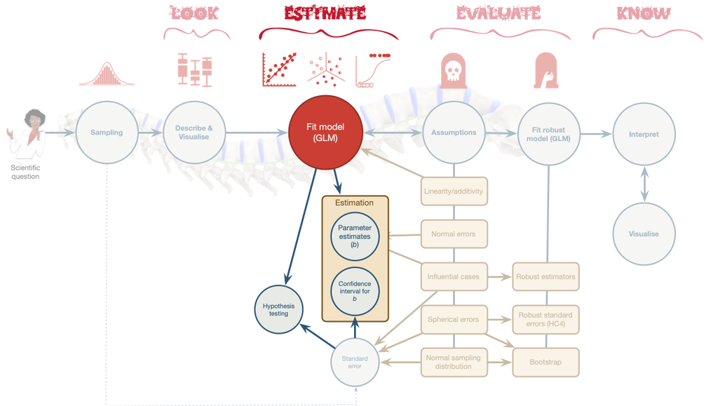

## Slide 4

## Slide 5 (new section): Extending the model

## Slide 6: Birnbaum revisited

[figure not shown]

- Does playing hard to get work?<sup>1</sup>
- Heterosexual participants conversed with an opposite-sex confederate over Instant Messenger for 8 mins
- **Interest**: Final message coded for the number of expressions of romantic interest (range 0 to 4)
- **Hard to get**: 3 items rated 1 (not at all) and 5 (very much so)
  - *The other participant is hard to get*
- **Mate value**: 4 items rated 1 (not at all) and 5 (very much so)
  - *I perceive the other participant as a valued mate*

*Footnotes*

1. [Birnbaum et al. (2020). *Journal of Social and Personal Relationships*. Study 3.](https://doi.org/10.1177/0265407520927469)

## Slide 7: The model

$$\text{interest}_i = \hat{b}_0 + \hat{b}_1\text{hard to get}_i +e_i$$

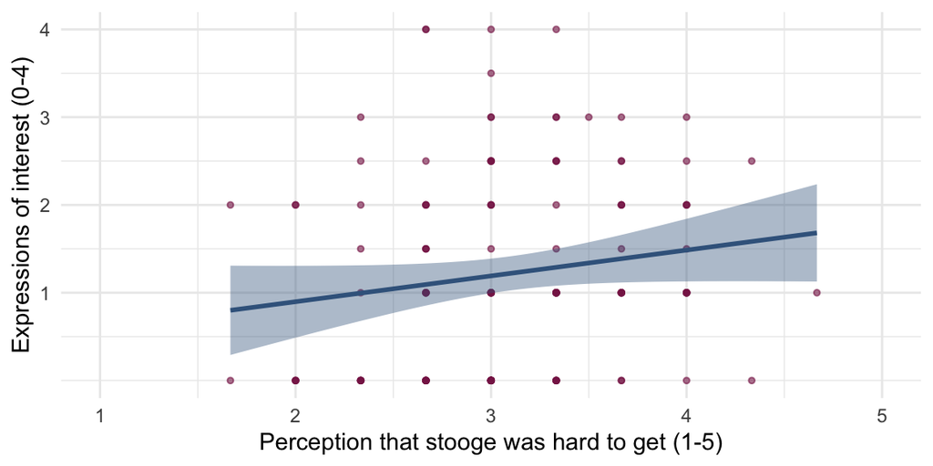

| Parameter | Coefficient | SE | 95% CI | t(126) | p |
| --- | --- | --- | --- | --- | --- |
| (Intercept) | 0.31 | 0.52 | (-0.73, 1.35) | 0.59 | 0.556 |
| hard to get | 0.29 | 0.17 | (-0.04, 0.62) | 1.76 | 0.080 |

> **Caution: Think about it!**
> - How do we extend the model to include mate value?

## Slide 8: Extending the linear model

$$\text{interest}_i = \hat{b}_0 + \hat{b}_1\text{hard to get}_i + \hat{b}_2\text{mate value}_i +e_i$$

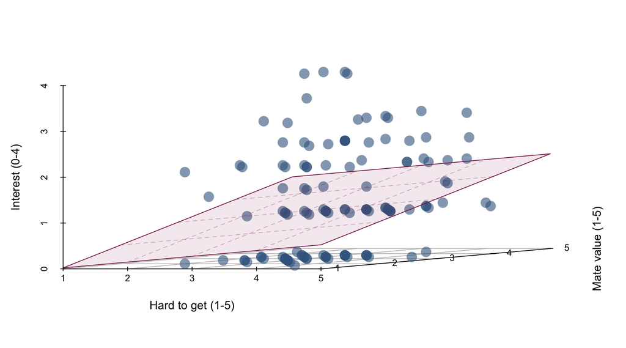

## Slide 9: Parameter estimates: hard to get

$\hat{\text{interest}}_i = -0.49 + 0.13\text{ hard to get}_i + 0.39\text{ mate value}_i$

| Parameter | Coefficient | SE | 95% CI | t(125) | p |
| --- | --- | --- | --- | --- | --- |
| (Intercept) | -0.49 | 0.62 | (-1.72, 0.74) | -0.79 | 0.432 |
| hard to get | 0.13 | 0.18 | (-0.23, 0.48) | 0.70 | 0.484 |
| mate value | 0.39 | 0.17 | (0.05, 0.72) | 2.31 | 0.023 |

- As the perception that the other person was hard to get increased by 1 (on a scale from 1-5), **0.13** more expressions of interest were made (when mate value is constant)
  - This effect is not significant, $\hat{b}$ = 0.13 (-0.23, 0.48), *t*(125) = 0.70, *p* = 0.484
  - This is the effect of ‘hard to get’ on interest **adjusted for** the effect of ‘mate value’

## Slide 10: Parameter estimates: mate value

$\hat{\text{interest}}_i = -0.49 + 0.13\text{ hard to get}_i + 0.39\text{ mate value}_i$

| Parameter | Coefficient | SE | 95% CI | t(125) | p |
| --- | --- | --- | --- | --- | --- |
| (Intercept) | -0.49 | 0.62 | (-1.72, 0.74) | -0.79 | 0.432 |
| hard to get | 0.13 | 0.18 | (-0.23, 0.48) | 0.70 | 0.484 |
| mate value | 0.39 | 0.17 | (0.05, 0.72) | 2.31 | 0.023 |

- As the perception of mate value increased by 1 (on a scale from 1-5), **0.39** more expressions of interest were made (when perceptions of being hard to get are constant)
  - This effect is significant, $\hat{b}$ = 0.39 (0.05, 0.72), *t*(125) = 2.31, *p* = 0.023
  - This is the effect of ‘mate value’ on interest **adjusted for** the effect of ‘hard to get’

## Slide 11: How to enter predictors

- Hierarchical
  - Experimenter decides the order in which variables are entered into the model
  - Best for theory testing
- Forced entry
  - All predictors are entered simultaneously
- Stepwise
  - Predictors are selected using their semi-partial correlation with the outcome
  - The model is unlikely to replicate in other samples (i.e., can produce spurious results)
  - Use only for exploratory analysis

## Slide 12 (new section): When a hierarchical model gets you dressed

## Slide 13

Video clip: [arlo hierarchical small](https://profandyfield.github.io/statistics_lectures/ds_03_fit/media/arlo_hierarchical_small.mp4)

## Slide 14 (new section): When a stepwise model gets you dressed

## Slide 15

Video clip: [arlo stepwise small](https://profandyfield.github.io/statistics_lectures/ds_03_fit/media/arlo_stepwise_small.mp4)

## Slide 16

Video clip: [arlo outtake small](https://profandyfield.github.io/statistics_lectures/ds_03_fit/media/arlo_outtake_small.mp4)

## Slide 17 (new section): Model fit

## Slide 18: How do we tell if a model is a good fit?

- Let’s look at a simple model: the mean
- How do we tell if it’s a good fit?
- With some help from Taylor Swift
  - The album **1989**
- Spotify produce measures of song content
  - Energy
  - Valence
  - Danceability

> “Energy is a measure from 0.0 to 1.0 and represents a perceptual measure of intensity and activity.” (Spotify, API)
- The `spotifyr` package scrapes this data!

## Slide 19: Is the average energy score a good fit?

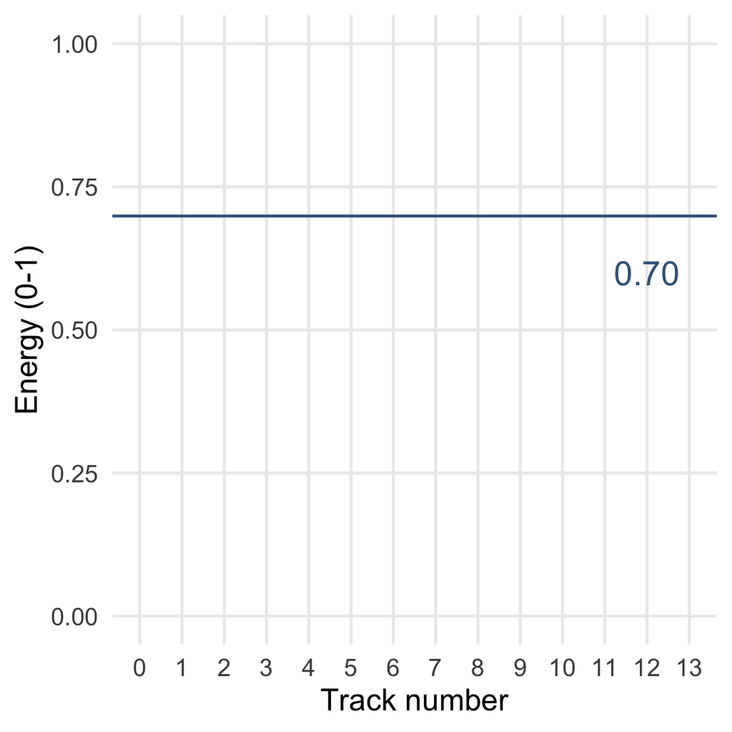

## Slide 20: Is the average energy score a good fit?

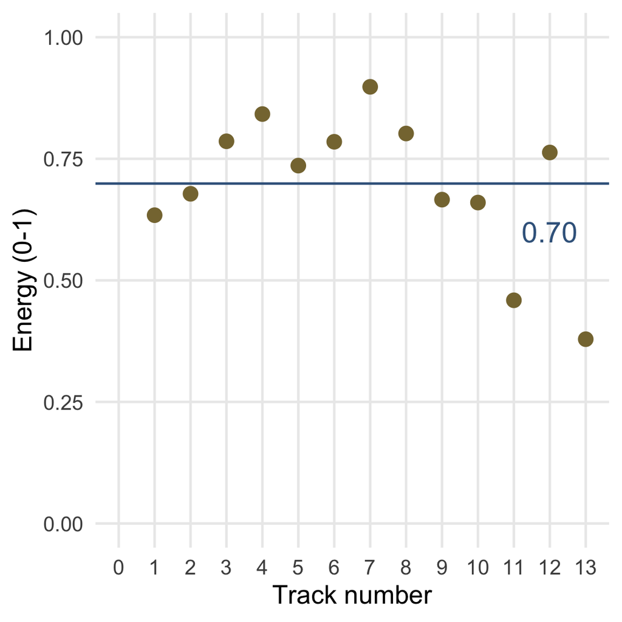

Audio clip: [taylor swift satan](https://profandyfield.github.io/statistics_lectures/ds_03_fit/media/taylor_swift_satan.mp3)

## Slide 21: Is the average energy score a good fit?

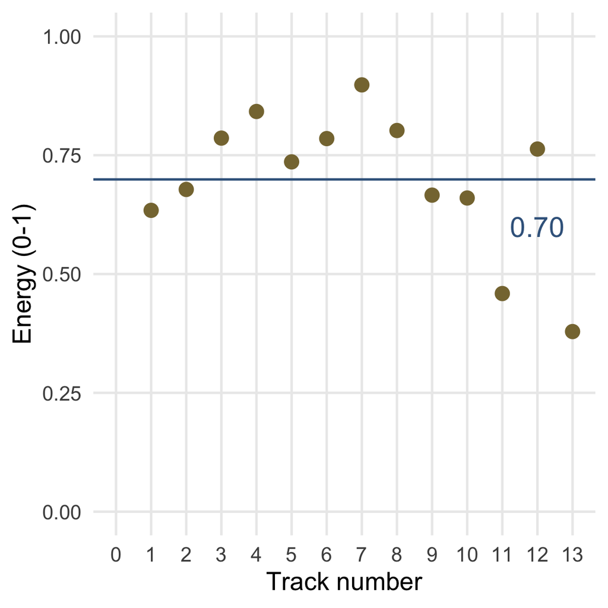

Audio clip: [taylor swift satan](https://profandyfield.github.io/statistics_lectures/ds_03_fit/media/taylor_swift_satan.mp3)

“Worship Satan for he is your dark lord and master,

Sacrifice goats to Beelzibub …

you know you want to”

## Slide 22: Is the average energy score a good fit?

## Slide 23

Video clip: [flight of icarus vancouver](https://profandyfield.github.io/statistics_lectures/ds_03_fit/media/flight_of_icarus_vancouver.mp4)

## Slide 24: Is the average energy score a good fit?

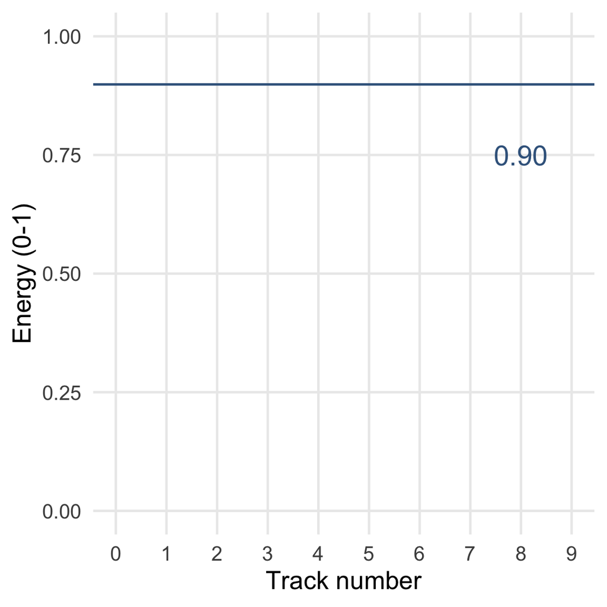

## Slide 25: Is the average energy score a good fit?

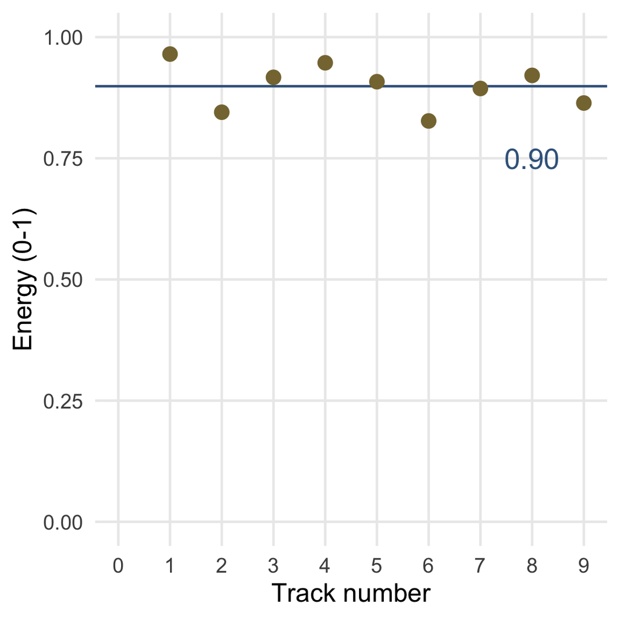

## Slide 26: Is the average energy score a good fit?

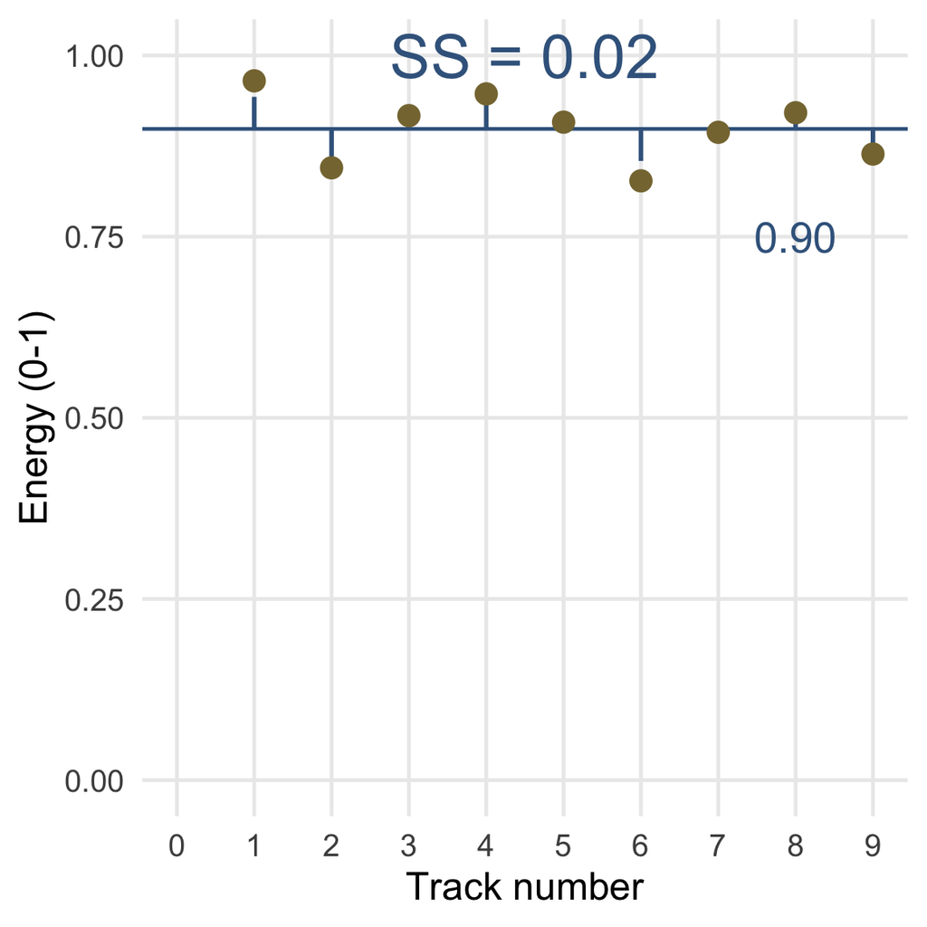

## Slide 27: Comparing sums of squares

- Sums of squares represent **total** error
- Because sums of squares are totals we can compare them only when they are based on the same number of scores.
- Alternatively, we factor in the number of scores
- We can get the **average** error by divide by a function of the number of scores
  - The degrees of freedom (the number of independent pieces of information)
  - The number of scores minus the number of parameters
  - $\text{df} = N-p$

$$\begin{aligned} \text{MS} &= \frac{\text{SS}}{N-p} \\ &= \frac{\text{SS}}{N-1} \end{aligned}$$

## Slide 28: Is the average energy score a good fit?

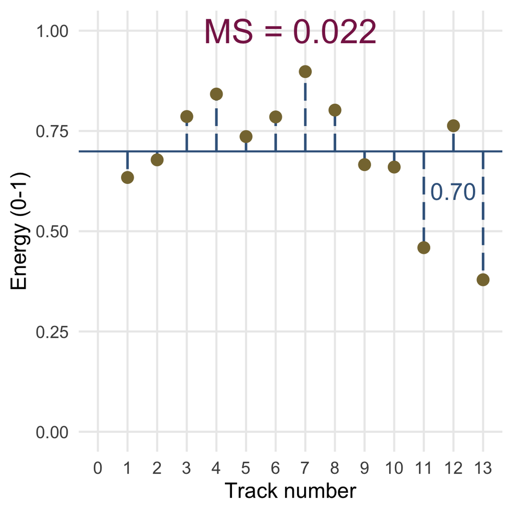

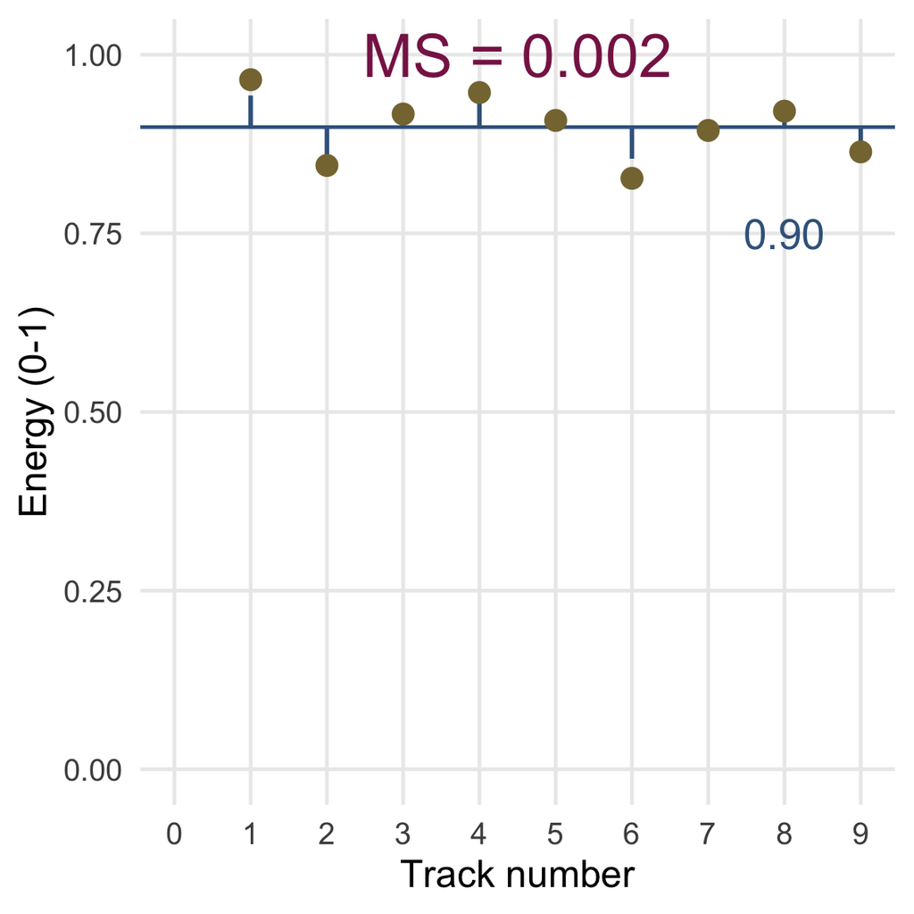

## Slide 29: Illusory Truth Effect (ITE)1

- Repetition increases perceived truthfulness (Hasher et al., 1977)
- This is equally true for plausible and implausible statements (Fazio et al., 2019)

*Footnotes*

1. Murray et al. (2020). https://doi.org/10.31234/osf.io/9evzc

## Slide 30

Video clip: [milton lecture amazing repeat](https://profandyfield.github.io/statistics_lectures/ds_03_fit/media/milton_lecture_amazing_repeat.mp4)

## Slide 31: Illusory Truth Effect (ITE)1

- Repetition increases perceived truthfulness (Hasher et al., 1977)
- This is equally true for plausible and implausible statements (Fazio et al., 2019)
- Worryingly, the effect is true for false political statements regardless of political ideology
  - Of 105 statements made by Donald Trump between 02/11/2016 and 9/10/2019 77 (73%) were only half true or worse.
  - In experiments, people exposed repeatedly to Trump statements rated them as more truthful than those who were not on a 6-point scale <sup>1</sup>
- Imagine a model that predicts ratings of truth of fake statements from number of exposures
  - Predictor: number of exposures
  - outcome: ratings of truth (0 = definitely false, 5 = definitely true)

*Footnotes*

1. Murray et al. (2020). https://doi.org/10.31234/osf.io/9evzc

## Slide 32: Testing the fit of the general linear model

To see whether the model is a reasonable ‘fit’ of the observed data we use the sum of squared errors (**SS**):

- **SS<sub>T</sub>**
  - Total variability (variability between scores and the mean)
- **SS<sub>R</sub>**
  - Total residual/error variability (variability between the model and the observed data)
  - How badly the model fits (in total)
- **SS<sub>M</sub>**
  - Total model variability (difference in variability between the model and the grand mean)
  - How much better the model is at predicting *Y* than the mean
  - How well the model fits (in total)

## Slide 33

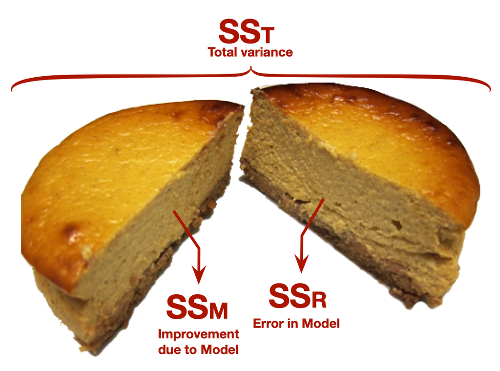

## Slide 34

$$\begin{aligned} \text{perceived truth}_i &= \hat{b}_0 + \hat{b}_1\text{repetition}_{i} + e_i \\ \hat{\text{perceived truth}}_i &= 1.28 + 0.54\text{ repetition}_{i} \\ \end{aligned}$$

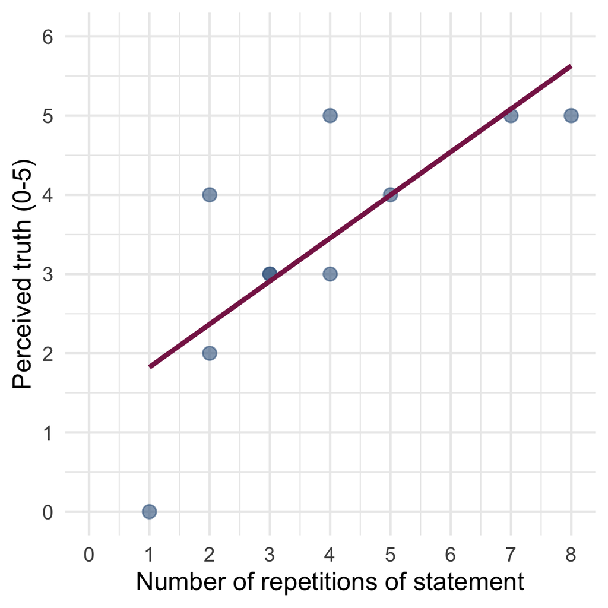

## Slide 35

### Total sum of squared error, SS<sub>T</sub>

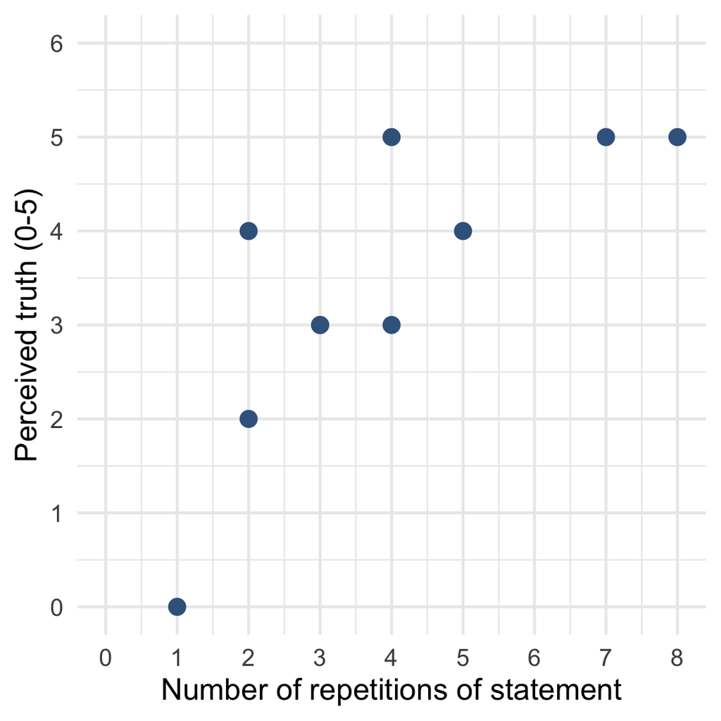

## Slide 36

### Total sum of squared error, SS<sub>T</sub>

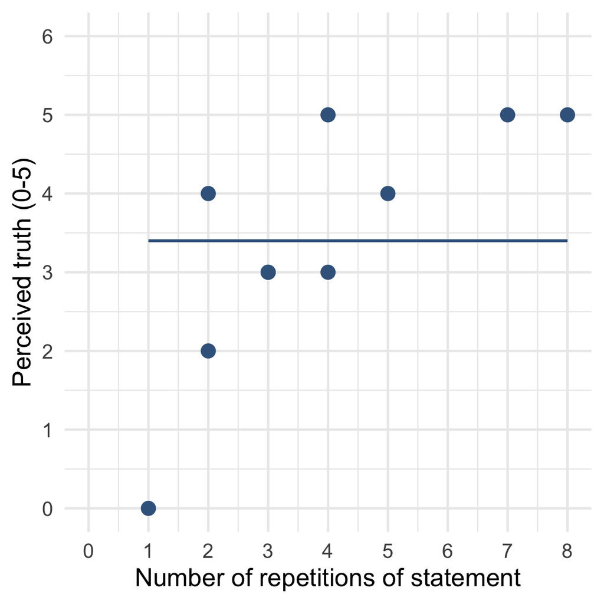

## Slide 37

### Total sum of squared error, SS<sub>T</sub>

|  | Reps | Truth | Predicted value | Error | Squared error |
| --- | --- | --- | --- | --- | --- |
|  | 1 | 0 | 3.4 | -3.4 | 11.56 |
|  | 2 | 2 | 3.4 | -1.4 | 1.96 |
|  | 2 | 4 | 3.4 | 0.6 | 0.36 |
|  | 3 | 3 | 3.4 | -0.4 | 0.16 |
|  | 3 | 3 | 3.4 | -0.4 | 0.16 |
|  | 4 | 3 | 3.4 | -0.4 | 0.16 |
|  | 4 | 5 | 3.4 | 1.6 | 2.56 |
|  | 5 | 4 | 3.4 | 0.6 | 0.36 |
|  | 7 | 5 | 3.4 | 1.6 | 2.56 |
|  | 8 | 5 | 3.4 | 1.6 | 2.56 |
| SS Total | — | — | — | — | 22.4 |

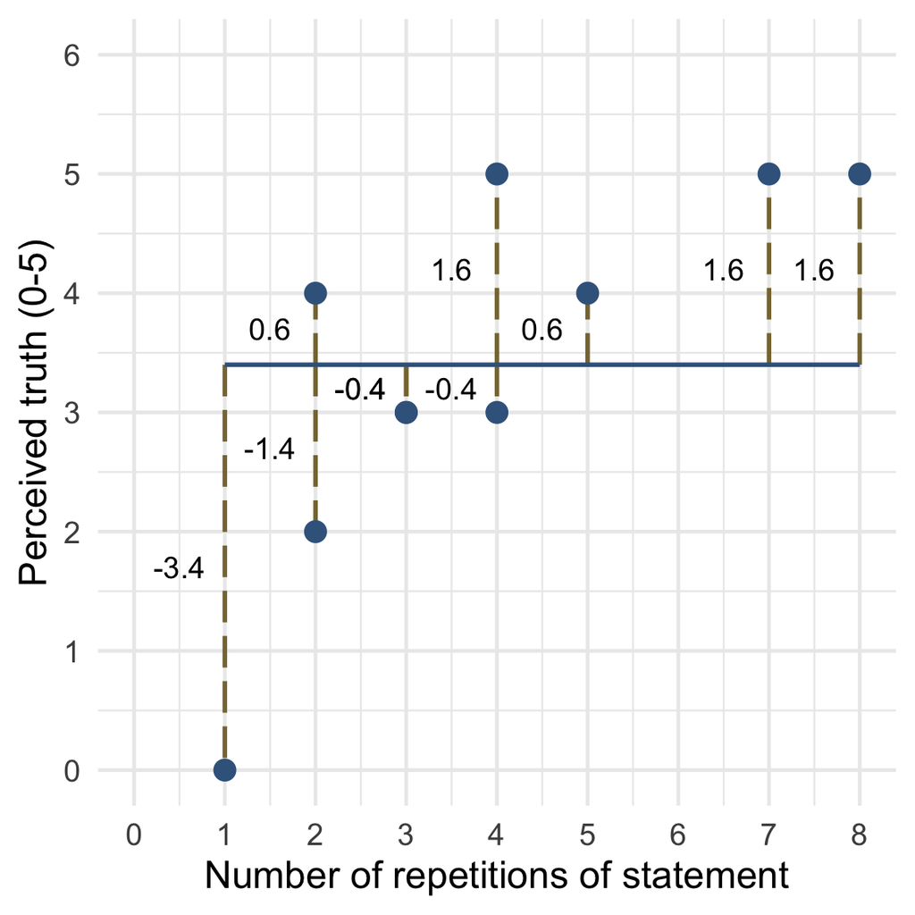

## Slide 38

### Total sum of squared errors, SS<sub>T</sub>

- Each SS has associated **degrees of freedom** (**df**)
- The *df* is the amount of *independent information* available to compute SS
- To begin with we have *N* pieces of independent information
- For every parameter (*p*) estimated we lose 1 piece of independent information
- To get SS<sub>T</sub> we estimate 1 parameter (the overall mean):

$$\begin{aligned} \text{df}_\text{T} &= N-p \\ &= 10 - 1 \\ &= 9 \end{aligned}$$

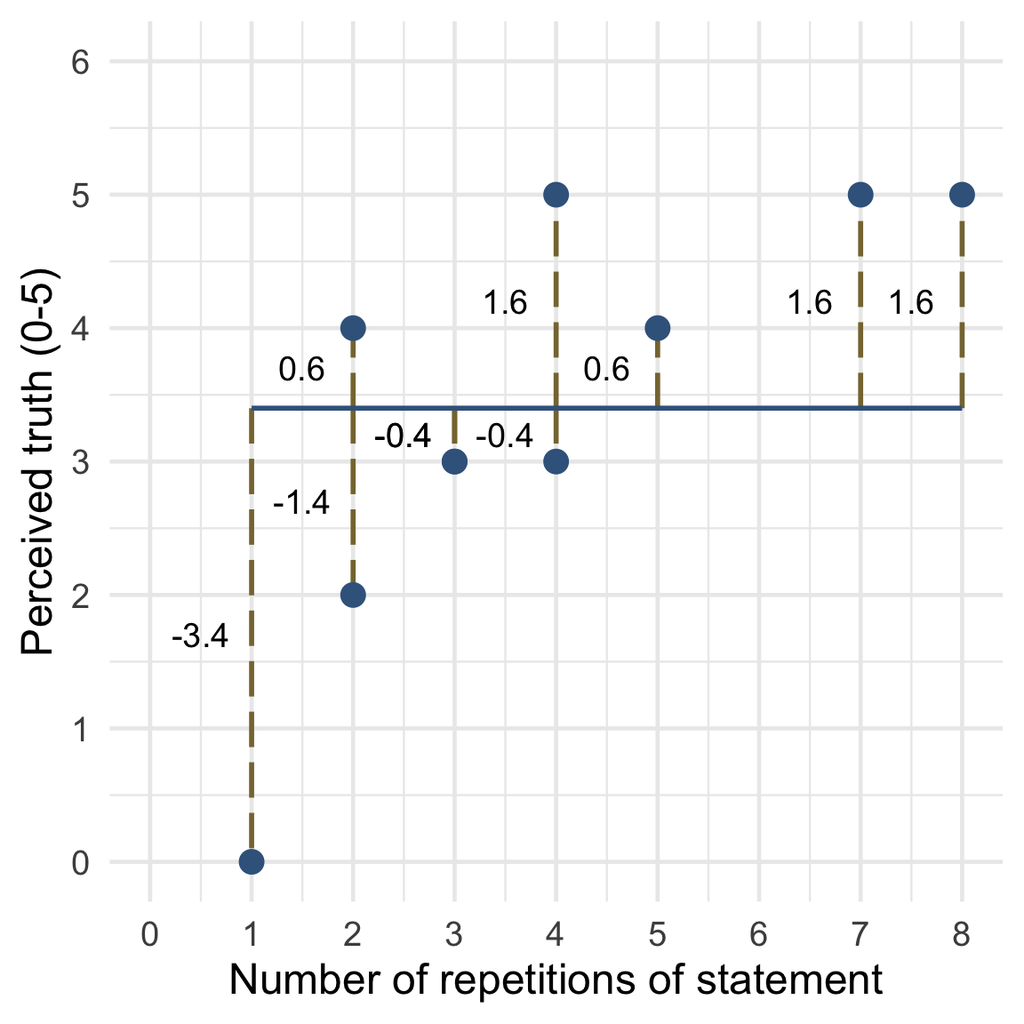

## Slide 39

### Residual sum of squared errors, SS<sub>R</sub>

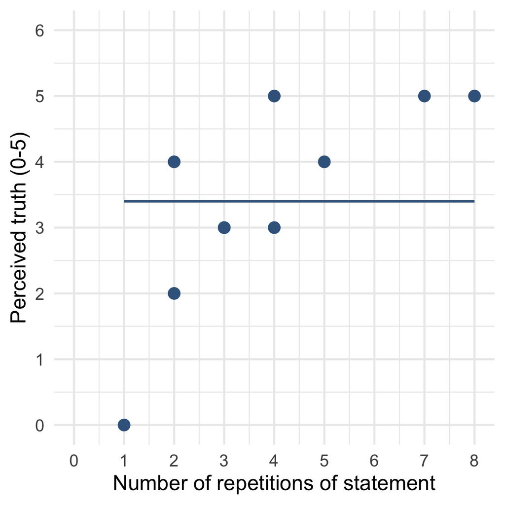

## Slide 40

### Residual sum of squared errors, SS<sub>R</sub>

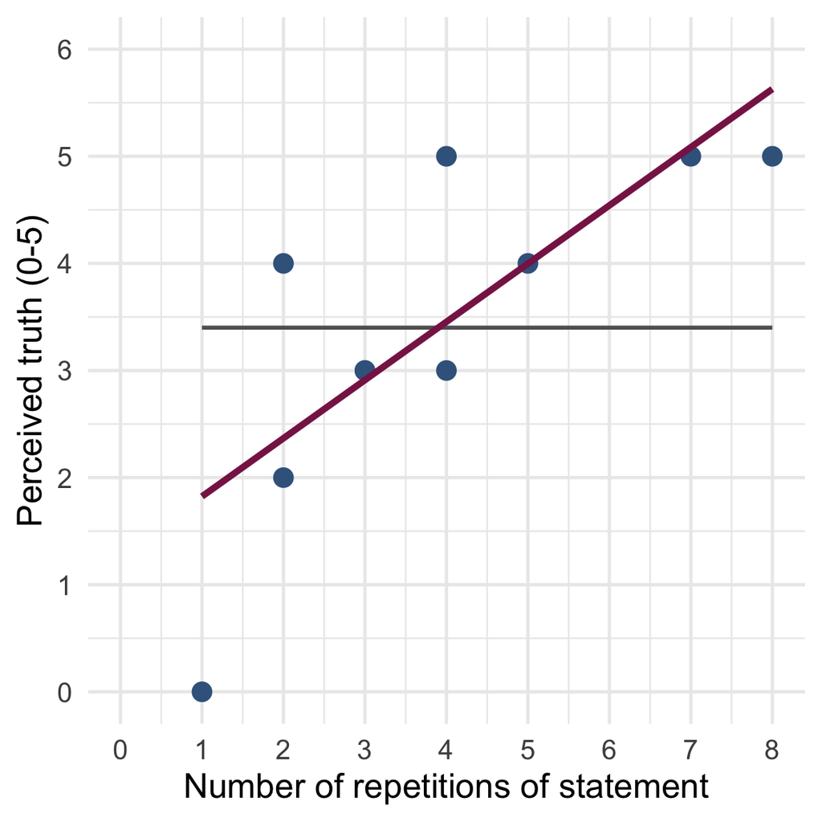

## Slide 41

### Residual sum of squared errors, SS<sub>R</sub>

|  | Reps | Truth | Predicted value | Error | Squared error |
| --- | --- | --- | --- | --- | --- |
|  | 1 | 0 | 1.82 | -1.82 | 3.31 |
|  | 2 | 2 | 2.37 | -0.37 | 0.14 |
|  | 2 | 4 | 2.37 | 1.63 | 2.66 |
|  | 3 | 3 | 2.91 | 0.09 | 0.01 |
|  | 3 | 3 | 2.91 | 0.09 | 0.01 |
|  | 4 | 3 | 3.45 | -0.45 | 0.20 |
|  | 4 | 5 | 3.45 | 1.55 | 2.40 |
|  | 5 | 4 | 4.00 | 0.00 | 0.00 |
|  | 7 | 5 | 5.08 | -0.08 | 0.01 |
|  | 8 | 5 | 5.63 | -0.63 | 0.40 |
| SS Residual | — | — | — | — | 9.14 |

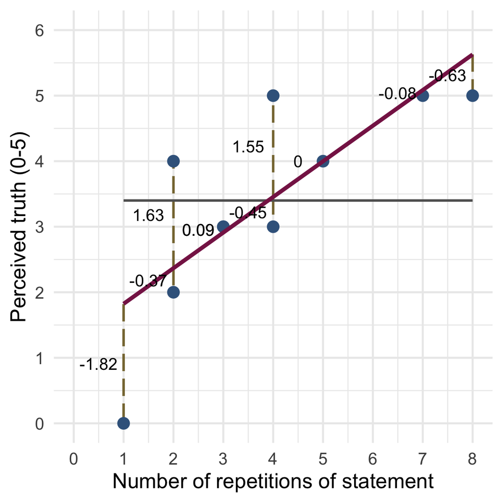

## Slide 42

### Residual sum of squared errors, SS<sub>R</sub>

- To begin with we have *N* pieces of independent information
- To get SS<sub>R</sub> we estimate two parameters (*b*<sub>0</sub> and *b*<sub>1</sub>):

$$\begin{aligned} \text{df}_\text{R} &= N-p \\ &= 10 - 2 \\ &= 8 \end{aligned}$$

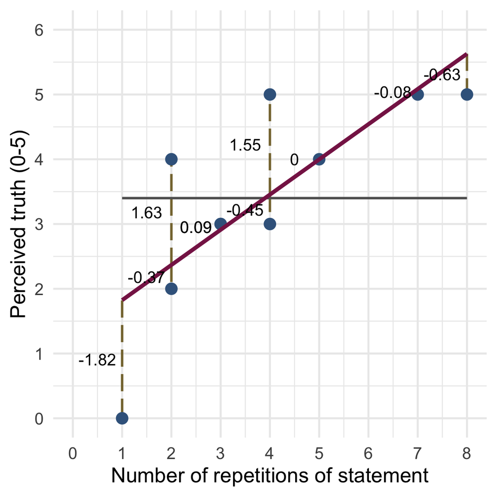

## Slide 43

### Model sum of squared errors, SS<sub>M</sub>

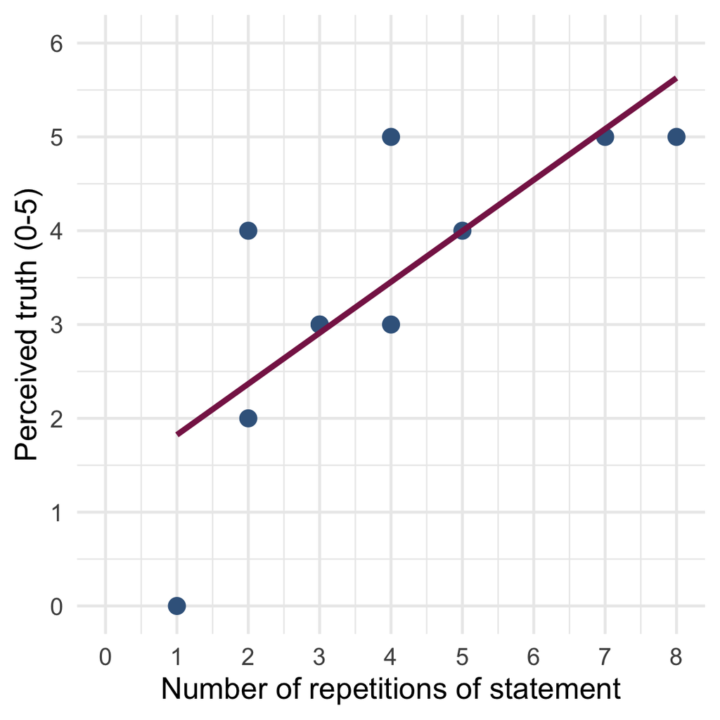

## Slide 44

### Model sum of squared errors, SS<sub>M</sub>

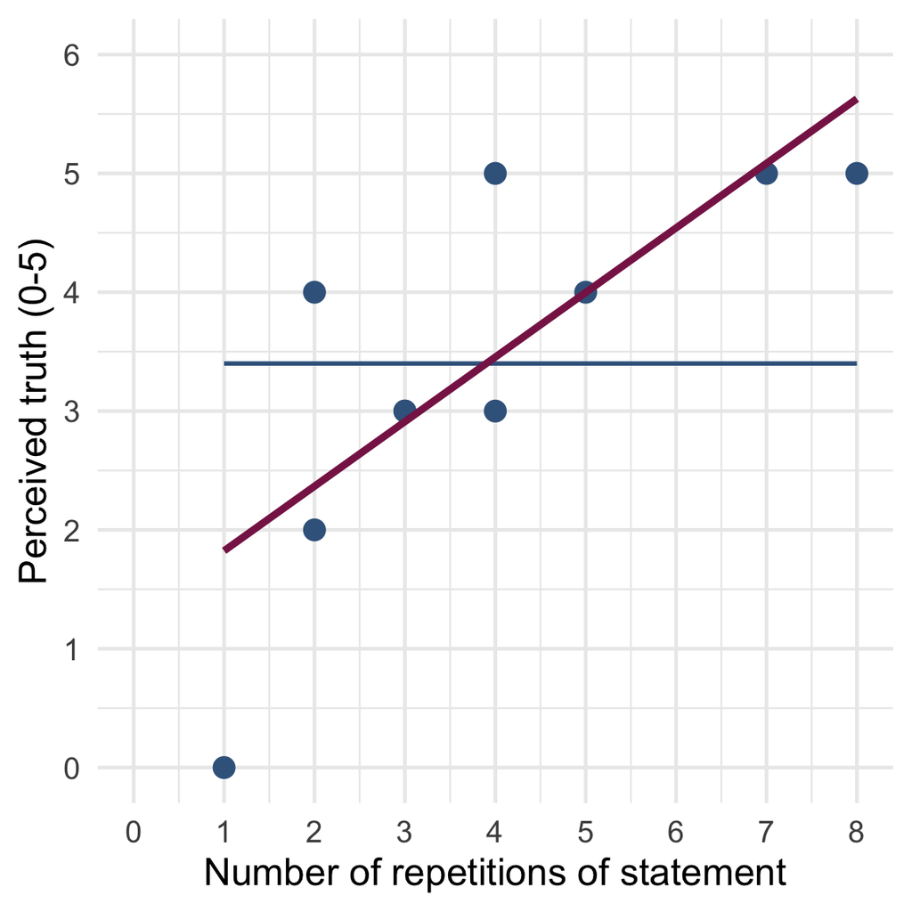

## Slide 45

### Model sum of squared errors, SS<sub>M</sub>

|  | Reps | Truth | Predicted value | Mean | Error | Squared error |
| --- | --- | --- | --- | --- | --- | --- |
|  | 1 | 0 | 1.82 | 3.4 | -1.58 | 2.50 |
|  | 2 | 2 | 2.37 | 3.4 | -1.03 | 1.06 |
|  | 2 | 4 | 2.37 | 3.4 | -1.03 | 1.06 |
|  | 3 | 3 | 2.91 | 3.4 | -0.49 | 0.24 |
|  | 3 | 3 | 2.91 | 3.4 | -0.49 | 0.24 |
|  | 4 | 3 | 3.45 | 3.4 | 0.05 | 0.00 |
|  | 4 | 5 | 3.45 | 3.4 | 0.05 | 0.00 |
|  | 5 | 4 | 4.00 | 3.4 | 0.60 | 0.36 |
|  | 7 | 5 | 5.08 | 3.4 | 1.68 | 2.82 |
|  | 8 | 5 | 5.63 | 3.4 | 2.23 | 4.97 |
| SS~M~ | — | — | — | — | — | 13.25 |

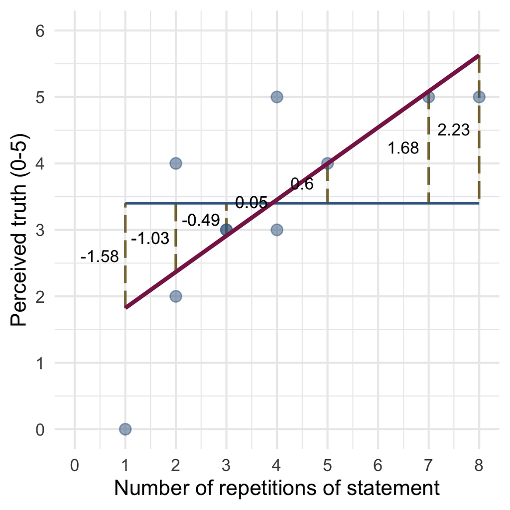

## Slide 46

### Model sum of squared errors, SS<sub>M</sub>

- The model is a rotation of the null model (the grand mean)
- Therefore, the null model and the estimated model are distinguished by 1 piece of independent information: the slope, *b*<sub>1</sub>
  - (Note, the intercept, *b*<sub>0</sub>, co-depends on the slope - it is not an independent piece of information)

$$\begin{aligned} \text{df}_\text{M} &= \text{df}_\text{T} - \text{df}_\text{R} \\ &= 9 - 8 \\ &= 1 \end{aligned}$$

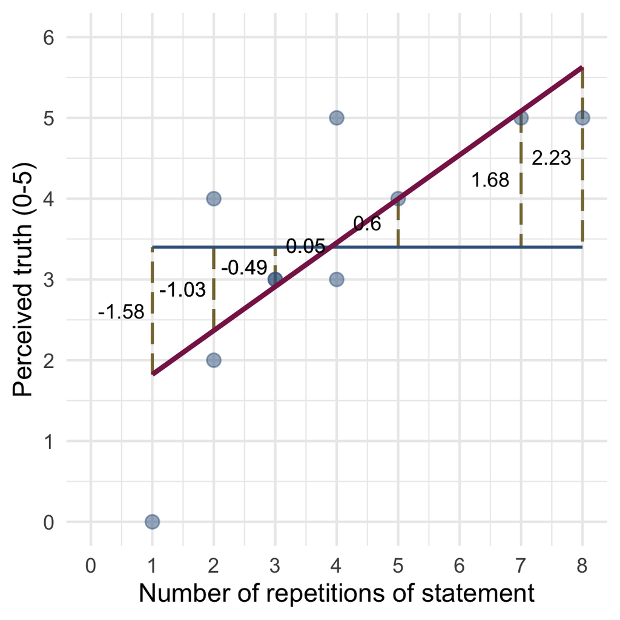

## Slide 47

$$\begin{aligned} \text{SS}_\text{T} &= \text{SS}_\text{M} + \text{SS}_\text{R} \\ 22.40 &= 13.25 + 9.14 \end{aligned}$$

(Within rounding error)

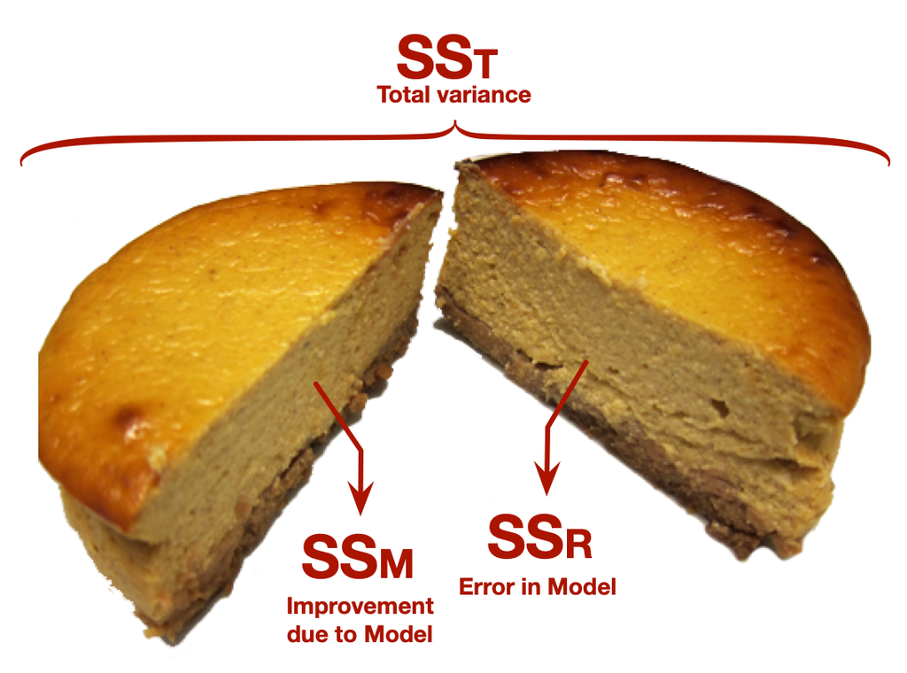

## Slide 48: Extending the linear model

$$\text{interest}_i = \hat{b}_0 + \hat{b}_1\text{hard to get}_i + \hat{b}_2\text{mate value}_i +e_i$$

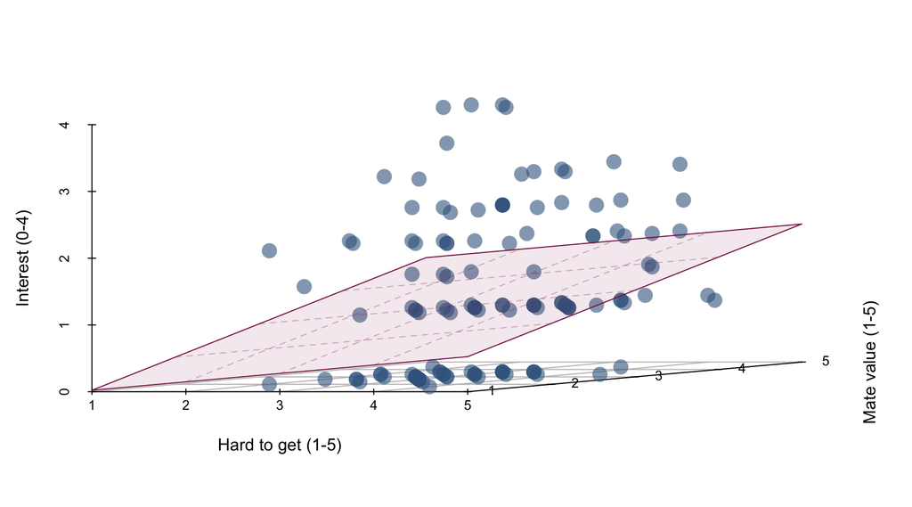

## Slide 49: Extending the linear model (SST)

$$\text{interest}_i = \hat{b}_0 + \hat{b}_1\text{hard to get}_i + \hat{b}_2\text{mate value}_i +e_i$$

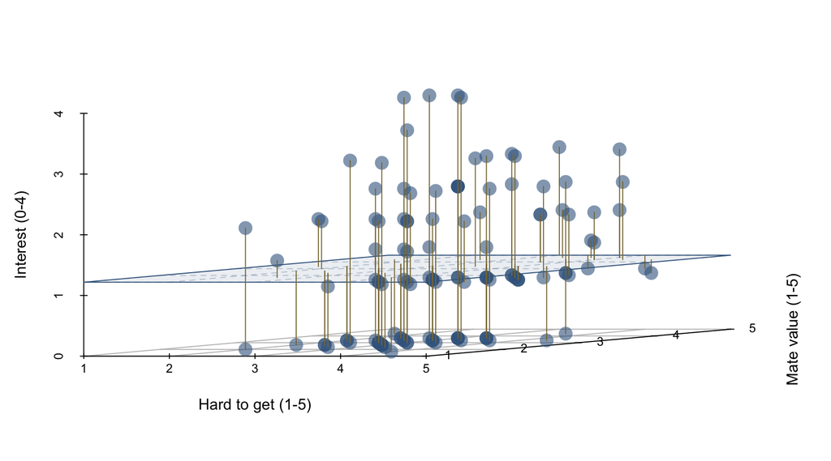

## Slide 50: Extending the linear model (SSR)

$$\text{interest}_i = \hat{b}_0 + \hat{b}_1\text{hard to get}_i + \hat{b}_2\text{mate value}_i +e_i$$

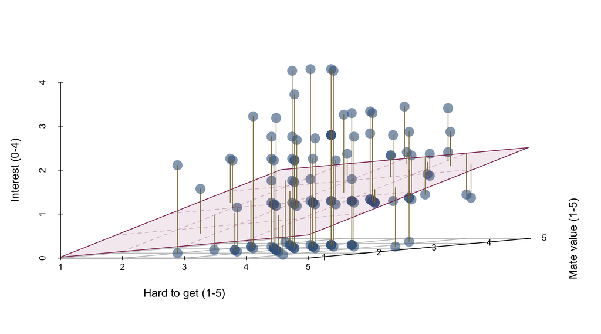